# Final Project

Hima Shanthi Rayapati, Khanh Bui, Serena Sabbara

2024-05-02

# Load the libraries

# **What is ANCOVA?**

### *Analysis of covariance (ANCOVA):*

A statistical technique used to compare means of two or more groups while accounting for the influence of other variables, called covariates.

Linear model that tests the influence of

- One categorical explanatory variable and
- One continuous explanatory variable
- One continuous response variable.

# **Why ANCOVA?**

### *Detect a difference in means of 2 or more independent groups, whilst controlling for scale covariates.*

- A covariate is not usually part of the main research question but could influence the dependent variable and therefore needs to be controlled for.

### *Help addressing several key challenges and providing valuable insights*

- Controlling for Covariates
- Improving Precision and Accuracy
- Addressing Confounding Variables

# **Possible goals of ANCOVA**

Determine the effects of the categorical and continuous variables on the response variable

1. The categorical and continuous variables on the response variable
2. The categorical variable(s) on the response variable(s) after removing the effect of the continuous variable
3. The categorical variable(s) on the relationship between the continuous variables(s) and the response variable

*Note: these goals are only met if there is no significant interaction between the categorical and continuous variables!*

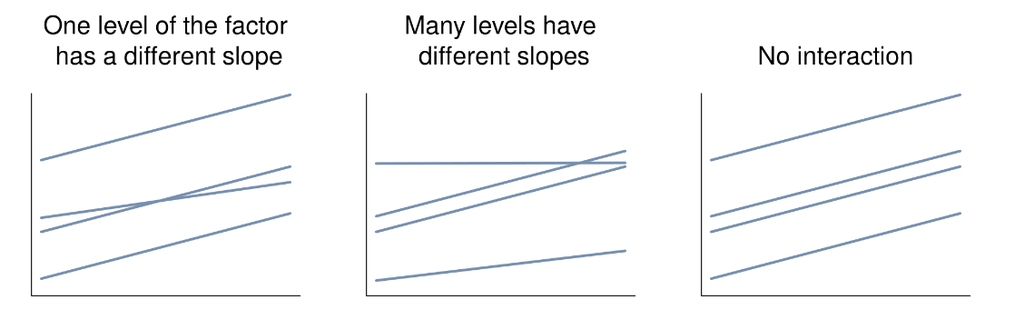

- In case of significant interaction, the scenario will look like graph 1 and 2

# **ANCOVA and ANOVA differences**

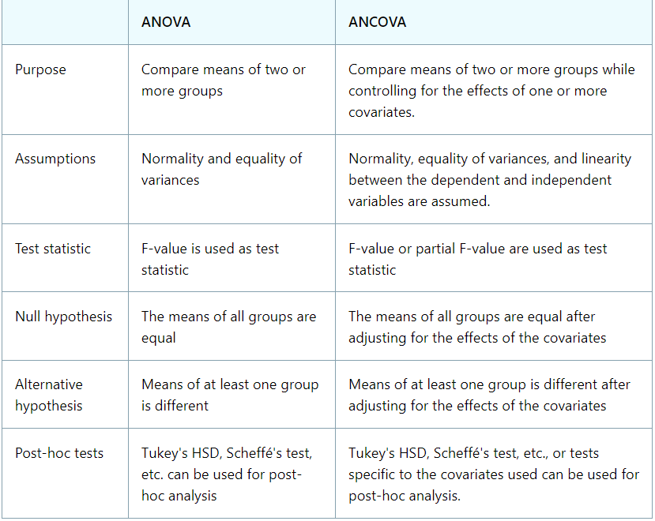

# Flowchart

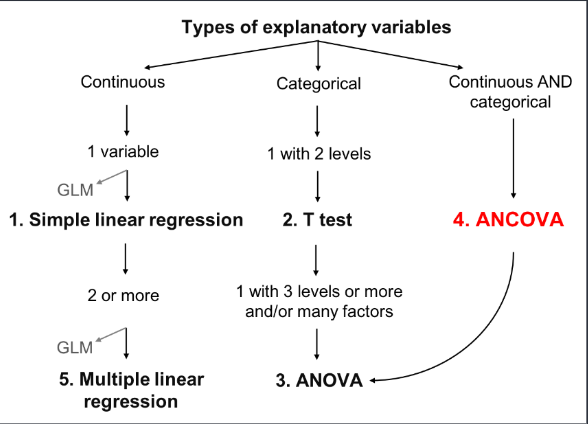

# **Our research question**

**Variables of Interest**

*Numeric response variables*: time_bp (time spent on work before the pandemic) and time_dp (time spent on work during a pandemic)

*Categorical explanatory variable*: Occupation

# **Load the data**

### *Hurdle*

- We got an error while trying to copy the path

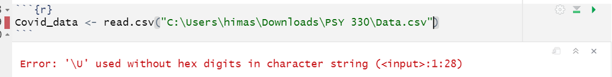

- Later changed it to:

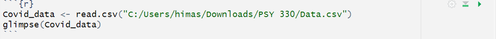

# Psychological Effects of COVID

- Survey taken in 2020 to understand people’s opinion on lockdown

```
## Rows: 1,175
## Columns: 22
## $ age            <chr> "19-25", "Dec-18", "19-25", "19-25", "19-25", "19-25", …
## $ gender         <chr> "Male", "Male", "Male", "Male", "Female", "Male", "Male…
## $ occupation     <chr> "Student in College", "Student in School", "Student in …
## $ line_of_work   <chr> "", "", "", "", "", "", "", "", "", "", "", "", "", "",…
## $ time_bp        <int> 7, 7, 7, 7, 7, 5, 5, 7, 5, 7, 7, 5, 7, 7, 9, 11, 7, 7, …
## $ time_dp        <int> 5, 11, 7, 7, 7, 7, 4, 9, 9, 7, 4, 9, 11, 7, 11, 5, 5, 9…
## $ travel_time    <dbl> 0.5, 0.5, 1.5, 1.5, 1.5, 0.5, 0.5, 0.5, 0.5, 1.5, 0.5, …
## $ easeof_online  <int> 3, 4, 2, 3, 2, 4, 1, 3, 1, 2, 2, 3, 5, 2, 2, 5, 2, 5, 2…
## $ home_env       <int> 3, 2, 2, 1, 2, 4, 3, 2, 2, 2, 1, 3, 4, 1, 3, 2, 3, 3, 4…
## $ prod_inc       <dbl> 0.0, -0.5, 1.0, 0.0, 0.0, -1.0, 0.5, 0.0, 1.0, 0.0, 0.0…
## $ sleep_bal      <dbl> 0.0, 0.5, 0.0, 1.0, 0.0, -1.0, 0.5, -0.5, 1.0, 0.0, -0.…
## $ new_skill      <dbl> 0.5, -1.0, 0.5, 0.5, 0.0, 0.0, 1.0, -0.5, 1.0, 0.0, 0.5…
## $ fam_connect    <dbl> 1.0, 1.0, 0.5, 0.0, 0.0, -0.5, 0.5, -1.0, 1.0, -1.0, 0.…
## $ relaxed        <dbl> -0.5, 1.0, 0.5, -1.0, 0.5, 0.0, 1.0, -0.5, 1.0, 0.0, 0.…
## $ self_time      <dbl> -0.5, 1.0, 0.5, -0.5, 0.0, 0.0, 1.0, 0.0, 1.0, 0.0, 0.5…
## $ like_hw        <int> 100, 1111, 1100, 100, 1010, 110, 1100, 1000, 1010, 1110…
## $ dislike_hw     <int> 1, 1110, 111, 1111, 1000, 1100, 1101, 1000, 100, 1111, …
## $ prefer         <chr> "Complete Physical Attendance", "Complete Physical Atte…
## $ certaindays_hw <chr> "Yes", "No", "Yes", "Yes", "Yes", "No", "Yes", "Yes", "…
## $ X              <lgl> NA, NA, NA, NA, NA, NA, NA, NA, NA, NA, NA, NA, NA, NA,…
## $ time_bp.1      <int> 7, 7, 7, 7, 7, 5, 5, 7, 5, 7, 7, 5, 7, 7, 9, 11, 7, 7, …
## $ travel.work    <lgl> NA, NA, NA, NA, NA, NA, NA, NA, NA, NA, NA, NA, NA, NA,…
```

# Pre-process the data

*Code used*

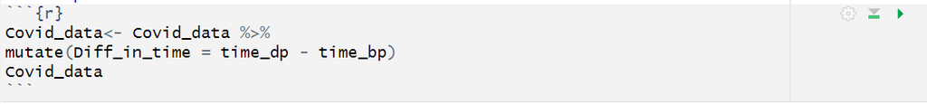

[output not shown]

[output cut: 7041 more lines]

# Visualize the data

*Code used*

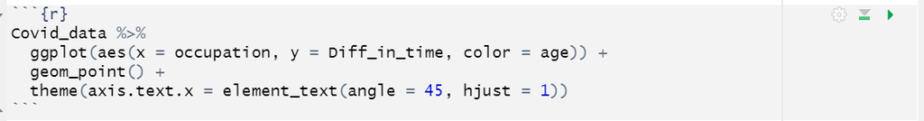

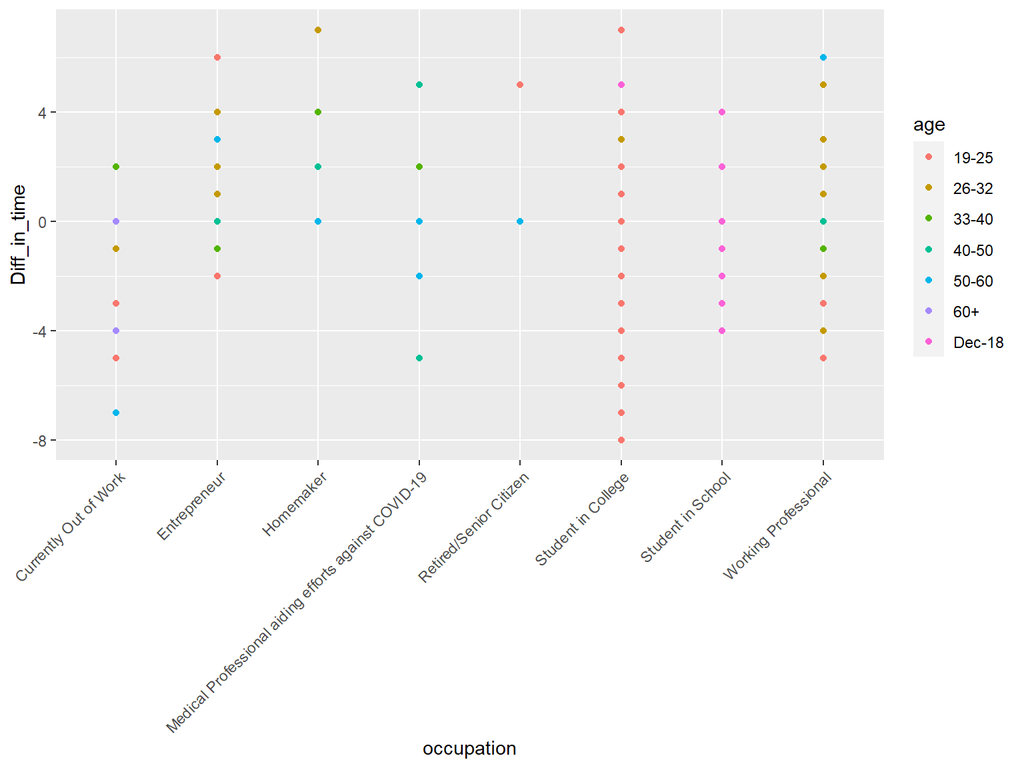

# Ancova using lm method

*Code used*

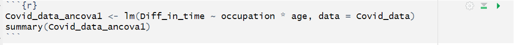

```
##
## Call:
## lm(formula = Diff_in_time ~ occupation * age, data = Covid_data)
##
## Residuals:
##     Min      1Q  Median      3Q     Max
## -7.6667 -0.7182  0.0952  1.2818  7.3333
##
## Coefficients: (25 not defined because of singularities)
##                                                                          Estimate
## (Intercept)                                                               -3.6667
## occupationEntrepreneur                                                     7.4167
## occupationHomemaker                                                        3.7895
## occupationMedical Professional aiding efforts against COVID-19             6.9048
## occupationRetired/Senior Citizen                                           8.6667
## occupationStudent in College                                               3.3333
## occupationStudent in School                                                3.5000
## occupationWorking Professional                                             3.4943
## age26-32                                                                   2.6667
## age33-40                                                                   5.6667
## age40-50                                                                   0.4545
## age50-60                                                                  -3.3333
## age60+                                                                    -0.1228
## ageDec-18                                                                 -0.6667
## occupationEntrepreneur:age26-32                                           -2.9881
## occupationHomemaker:age26-32                                               4.2105
## occupationMedical Professional aiding efforts against COVID-19:age26-32        NA
## occupationRetired/Senior Citizen:age26-32                                      NA
## occupationStudent in College:age26-32                                     -0.8333
## occupationStudent in School:age26-32                                           NA
## occupationWorking Professional:age26-32                                   -1.7760
## occupationEntrepreneur:age33-40                                           -9.9167
## occupationHomemaker:age33-40                                              -3.7895
## occupationMedical Professional aiding efforts against COVID-19:age33-40   -6.9048
## occupationRetired/Senior Citizen:age33-40                                      NA
## occupationStudent in College:age33-40                                          NA
## occupationStudent in School:age33-40                                           NA
## occupationWorking Professional:age33-40                                   -6.0166
## occupationEntrepreneur:age40-50                                           -4.1275
## occupationHomemaker:age40-50                                               2.0894
```

[output cut: 245 more lines]

```
## occupationStudent in School:age60+
## occupationWorking Professional:age60+
## occupationEntrepreneur:ageDec-18
## occupationHomemaker:ageDec-18
## occupationMedical Professional aiding efforts against COVID-19:ageDec-18
## occupationRetired/Senior Citizen:ageDec-18
## occupationStudent in College:ageDec-18
## occupationStudent in School:ageDec-18
## occupationWorking Professional:ageDec-18
## ---
## Signif. codes:  0 '***' 0.001 '**' 0.01 '*' 0.05 '.' 0.1 ' ' 1
##
## Residual standard error: 1.982 on 1144 degrees of freedom
## Multiple R-squared:  0.4748, Adjusted R-squared:  0.461
## F-statistic: 34.48 on 30 and 1144 DF,  p-value: < 2.2e-16
```

# Summary

*Code used*

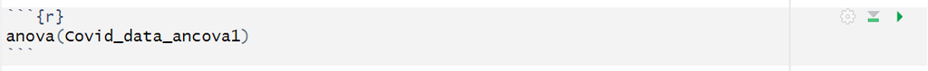

```
## Analysis of Variance Table
##
## Response: Diff_in_time
##                  Df Sum Sq Mean Sq F value    Pr(>F)
## occupation        7 3287.3  469.61 119.501 < 2.2e-16 ***
## age               6  281.3   46.88  11.929 5.067e-13 ***
## occupation:age   17  495.8   29.17   7.422 < 2.2e-16 ***
## Residuals      1144 4495.6    3.93
## ---
## Signif. codes:  0 '***' 0.001 '**' 0.01 '*' 0.05 '.' 0.1 ' ' 1
```

# Ancova using aov method

*Code used*

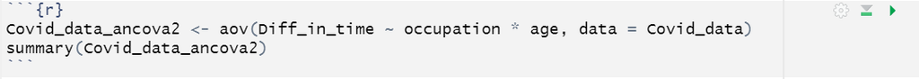

```
##                  Df Sum Sq Mean Sq F value   Pr(>F)
## occupation        7   3287   469.6 119.501  < 2e-16 ***
## age               6    281    46.9  11.929 5.07e-13 ***
## occupation:age   17    496    29.2   7.422  < 2e-16 ***
## Residuals      1144   4496     3.9
## ---
## Signif. codes:  0 '***' 0.001 '**' 0.01 '*' 0.05 '.' 0.1 ' ' 1
```

# QQ- plot (Quantile - Quantile plot)

- Draws correlation between a given sample and the normal distribution
- Used to visually check the normality of the data

*Code used*

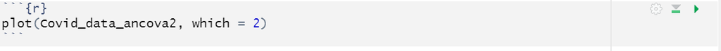

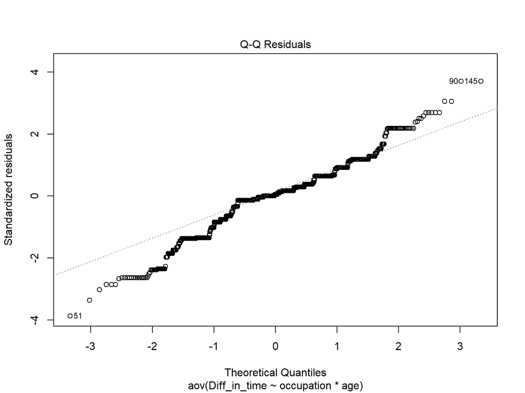